# Practical ML Final Assignment

SuperIban

March 20, 2019

Background Using devices such as Jawbone Up, Nike FuelBand, and Fitbit it is now possible to collect a large amount of data about personal activity relatively inexpensively. These type of devices are part of the quantified self movement - a group of enthusiasts who take measurements about themselves regularly to improve their health, to find patterns in their behavior, or because they are tech geeks. One thing that people regularly do is quantify how much of a particular activity they do, but they rarely quantify how well they do it. In this project, your goal will be to use data from accelerometers on the belt, forearm, arm, and dumbell of 6 participants. They were asked to perform barbell lifts correctly and incorrectly in 5 different ways. More information is available from the website here: http://groupware.les.inf.puc-rio.br/har (see the section on the Weight Lifting Exercise Dataset).

Data The training data for this project are available here: https://d396qusza40orc.cloudfront.net/predmachlearn/pml-training.csv

The test data are available here: https://d396qusza40orc.cloudfront.net/predmachlearn/pml-testing.csv

The data for this project come from this source: http://groupware.les.inf.puc-rio.br/har. If you use the document you create for this class for any purpose please cite them as they have been very generous in allowing their data to be used for this kind of assignment.

Goal The goal of your project is to predict the manner in which they did the exercise. This is the âclasseâ variable in the training set. You may use any of the other variables to predict with. You should create a report describing how you built your model, how you used cross validation, what you think the expected out of sample error is, and why you made the choices you did. You will also use your prediction model to predict 20 different test cases.

## Loading the Libraries

```r
library(caret)
library(randomForest)
```

## Getting the Data

```r
trainUrl <-"https://d396qusza40orc.cloudfront.net/predmachlearn/pml-training.csv"
testUrl <- "https://d396qusza40orc.cloudfront.net/predmachlearn/pml-testing.csv"
```

## Read the Data

```r
trainingFile <- read.csv(url(trainUrl), na.strings=c("NA","#DIV/0!",""))
testingFile <- read.csv(url(testUrl), na.strings=c("NA","#DIV/0!",""))
ncol(testingFile)
```

```
## [1] 160
```

```r
sapply(testingFile, class)
```

```
##                        X                user_name     raw_timestamp_part_1
##                "integer"                 "factor"                "integer"
##     raw_timestamp_part_2           cvtd_timestamp               new_window
##                "integer"                 "factor"                 "factor"
##               num_window                roll_belt               pitch_belt
##                "integer"                "numeric"                "numeric"
##                 yaw_belt         total_accel_belt       kurtosis_roll_belt
##                "numeric"                "integer"                "logical"
##      kurtosis_picth_belt        kurtosis_yaw_belt       skewness_roll_belt
##                "logical"                "logical"                "logical"
##     skewness_roll_belt.1        skewness_yaw_belt            max_roll_belt
##                "logical"                "logical"                "logical"
##           max_picth_belt             max_yaw_belt            min_roll_belt
##                "logical"                "logical"                "logical"
##           min_pitch_belt             min_yaw_belt      amplitude_roll_belt
##                "logical"                "logical"                "logical"
##     amplitude_pitch_belt       amplitude_yaw_belt     var_total_accel_belt
##                "logical"                "logical"                "logical"
##            avg_roll_belt         stddev_roll_belt            var_roll_belt
##                "logical"                "logical"                "logical"
##           avg_pitch_belt        stddev_pitch_belt           var_pitch_belt
##                "logical"                "logical"                "logical"
##             avg_yaw_belt          stddev_yaw_belt             var_yaw_belt
##                "logical"                "logical"                "logical"
##             gyros_belt_x             gyros_belt_y             gyros_belt_z
##                "numeric"                "numeric"                "numeric"
##             accel_belt_x             accel_belt_y             accel_belt_z
##                "integer"                "integer"                "integer"
##            magnet_belt_x            magnet_belt_y            magnet_belt_z
##                "integer"                "integer"                "integer"
##                 roll_arm                pitch_arm                  yaw_arm
##                "numeric"                "numeric"                "numeric"
##          total_accel_arm            var_accel_arm             avg_roll_arm
##                "integer"                "logical"                "logical"
##          stddev_roll_arm             var_roll_arm            avg_pitch_arm
##                "logical"                "logical"                "logical"
##         stddev_pitch_arm            var_pitch_arm              avg_yaw_arm
##                "logical"                "logical"                "logical"
##           stddev_yaw_arm              var_yaw_arm              gyros_arm_x
##                "logical"                "logical"                "numeric"
```

[output cut: 53 more lines]

```
##                "logical"                "integer"                "logical"
##         avg_roll_forearm      stddev_roll_forearm         var_roll_forearm
##                "logical"                "logical"                "logical"
##        avg_pitch_forearm     stddev_pitch_forearm        var_pitch_forearm
##                "logical"                "logical"                "logical"
##          avg_yaw_forearm       stddev_yaw_forearm          var_yaw_forearm
##                "logical"                "logical"                "logical"
##          gyros_forearm_x          gyros_forearm_y          gyros_forearm_z
##                "numeric"                "numeric"                "numeric"
##          accel_forearm_x          accel_forearm_y          accel_forearm_z
##                "integer"                "integer"                "integer"
##         magnet_forearm_x         magnet_forearm_y         magnet_forearm_z
##                "integer"                "integer"                "integer"
##               problem_id
##                "integer"
```

```r
ncol(trainingFile)
```

```
## [1] 160
```

```r
sapply(trainingFile, class)
```

```
##                        X                user_name     raw_timestamp_part_1
##                "integer"                 "factor"                "integer"
##     raw_timestamp_part_2           cvtd_timestamp               new_window
##                "integer"                 "factor"                 "factor"
##               num_window                roll_belt               pitch_belt
##                "integer"                "numeric"                "numeric"
##                 yaw_belt         total_accel_belt       kurtosis_roll_belt
##                "numeric"                "integer"                "numeric"
##      kurtosis_picth_belt        kurtosis_yaw_belt       skewness_roll_belt
##                "numeric"                "logical"                "numeric"
##     skewness_roll_belt.1        skewness_yaw_belt            max_roll_belt
##                "numeric"                "logical"                "numeric"
##           max_picth_belt             max_yaw_belt            min_roll_belt
##                "integer"                "numeric"                "numeric"
##           min_pitch_belt             min_yaw_belt      amplitude_roll_belt
##                "integer"                "numeric"                "numeric"
##     amplitude_pitch_belt       amplitude_yaw_belt     var_total_accel_belt
##                "integer"                "numeric"                "numeric"
##            avg_roll_belt         stddev_roll_belt            var_roll_belt
##                "numeric"                "numeric"                "numeric"
##           avg_pitch_belt        stddev_pitch_belt           var_pitch_belt
##                "numeric"                "numeric"                "numeric"
##             avg_yaw_belt          stddev_yaw_belt             var_yaw_belt
##                "numeric"                "numeric"                "numeric"
##             gyros_belt_x             gyros_belt_y             gyros_belt_z
##                "numeric"                "numeric"                "numeric"
##             accel_belt_x             accel_belt_y             accel_belt_z
##                "integer"                "integer"                "integer"
##            magnet_belt_x            magnet_belt_y            magnet_belt_z
##                "integer"                "integer"                "integer"
##                 roll_arm                pitch_arm                  yaw_arm
##                "numeric"                "numeric"                "numeric"
##          total_accel_arm            var_accel_arm             avg_roll_arm
##                "integer"                "numeric"                "numeric"
##          stddev_roll_arm             var_roll_arm            avg_pitch_arm
##                "numeric"                "numeric"                "numeric"
##         stddev_pitch_arm            var_pitch_arm              avg_yaw_arm
##                "numeric"                "numeric"                "numeric"
##           stddev_yaw_arm              var_yaw_arm              gyros_arm_x
##                "numeric"                "numeric"                "numeric"
```

[output cut: 53 more lines]

```
##                "numeric"                "integer"                "numeric"
##         avg_roll_forearm      stddev_roll_forearm         var_roll_forearm
##                "numeric"                "numeric"                "numeric"
##        avg_pitch_forearm     stddev_pitch_forearm        var_pitch_forearm
##                "numeric"                "numeric"                "numeric"
##          avg_yaw_forearm       stddev_yaw_forearm          var_yaw_forearm
##                "numeric"                "numeric"                "numeric"
##          gyros_forearm_x          gyros_forearm_y          gyros_forearm_z
##                "numeric"                "numeric"                "numeric"
##          accel_forearm_x          accel_forearm_y          accel_forearm_z
##                "integer"                "integer"                "integer"
##         magnet_forearm_x         magnet_forearm_y         magnet_forearm_z
##                "integer"                "numeric"                "numeric"
##                   classe
##                 "factor"
```

## Output

testing file 20 obs of 160 variables Training file 19622 of 160 variables

## Subset of meaningfull data

```r
classe <- trainingFile$classe
trainingRemove <- grepl("^X|timestamp|window", names(trainingFile))
trainingFile <- trainingFile[, !trainingRemove]
testingRemove <- grepl("^X|timestamp|window", names(testingFile))
testingFile <- testingFile[, !testingRemove]

ncol(testingFile)
```

```
## [1] 154
```

```r
sapply(testingFile, class)
```

```
##                user_name                roll_belt               pitch_belt
##                 "factor"                "numeric"                "numeric"
##                 yaw_belt         total_accel_belt       kurtosis_roll_belt
##                "numeric"                "integer"                "logical"
##      kurtosis_picth_belt        kurtosis_yaw_belt       skewness_roll_belt
##                "logical"                "logical"                "logical"
##     skewness_roll_belt.1        skewness_yaw_belt            max_roll_belt
##                "logical"                "logical"                "logical"
##           max_picth_belt             max_yaw_belt            min_roll_belt
##                "logical"                "logical"                "logical"
##           min_pitch_belt             min_yaw_belt      amplitude_roll_belt
##                "logical"                "logical"                "logical"
##     amplitude_pitch_belt       amplitude_yaw_belt     var_total_accel_belt
##                "logical"                "logical"                "logical"
##            avg_roll_belt         stddev_roll_belt            var_roll_belt
##                "logical"                "logical"                "logical"
##           avg_pitch_belt        stddev_pitch_belt           var_pitch_belt
##                "logical"                "logical"                "logical"
##             avg_yaw_belt          stddev_yaw_belt             var_yaw_belt
##                "logical"                "logical"                "logical"
##             gyros_belt_x             gyros_belt_y             gyros_belt_z
##                "numeric"                "numeric"                "numeric"
##             accel_belt_x             accel_belt_y             accel_belt_z
##                "integer"                "integer"                "integer"
##            magnet_belt_x            magnet_belt_y            magnet_belt_z
##                "integer"                "integer"                "integer"
##                 roll_arm                pitch_arm                  yaw_arm
##                "numeric"                "numeric"                "numeric"
##          total_accel_arm            var_accel_arm             avg_roll_arm
##                "integer"                "logical"                "logical"
##          stddev_roll_arm             var_roll_arm            avg_pitch_arm
##                "logical"                "logical"                "logical"
##         stddev_pitch_arm            var_pitch_arm              avg_yaw_arm
##                "logical"                "logical"                "logical"
##           stddev_yaw_arm              var_yaw_arm              gyros_arm_x
##                "logical"                "logical"                "numeric"
##              gyros_arm_y              gyros_arm_z              accel_arm_x
##                "numeric"                "numeric"                "integer"
##              accel_arm_y              accel_arm_z             magnet_arm_x
##                "integer"                "integer"                "integer"
```

[output cut: 49 more lines]

```
##                "logical"                "integer"                "logical"
##         avg_roll_forearm      stddev_roll_forearm         var_roll_forearm
##                "logical"                "logical"                "logical"
##        avg_pitch_forearm     stddev_pitch_forearm        var_pitch_forearm
##                "logical"                "logical"                "logical"
##          avg_yaw_forearm       stddev_yaw_forearm          var_yaw_forearm
##                "logical"                "logical"                "logical"
##          gyros_forearm_x          gyros_forearm_y          gyros_forearm_z
##                "numeric"                "numeric"                "numeric"
##          accel_forearm_x          accel_forearm_y          accel_forearm_z
##                "integer"                "integer"                "integer"
##         magnet_forearm_x         magnet_forearm_y         magnet_forearm_z
##                "integer"                "integer"                "integer"
##               problem_id
##                "integer"
```

```r
ncol(trainingFile)
```

```
## [1] 154
```

```r
sapply(trainingFile, class)
```

```
##                user_name                roll_belt               pitch_belt
##                 "factor"                "numeric"                "numeric"
##                 yaw_belt         total_accel_belt       kurtosis_roll_belt
##                "numeric"                "integer"                "numeric"
##      kurtosis_picth_belt        kurtosis_yaw_belt       skewness_roll_belt
##                "numeric"                "logical"                "numeric"
##     skewness_roll_belt.1        skewness_yaw_belt            max_roll_belt
##                "numeric"                "logical"                "numeric"
##           max_picth_belt             max_yaw_belt            min_roll_belt
##                "integer"                "numeric"                "numeric"
##           min_pitch_belt             min_yaw_belt      amplitude_roll_belt
##                "integer"                "numeric"                "numeric"
##     amplitude_pitch_belt       amplitude_yaw_belt     var_total_accel_belt
##                "integer"                "numeric"                "numeric"
##            avg_roll_belt         stddev_roll_belt            var_roll_belt
##                "numeric"                "numeric"                "numeric"
##           avg_pitch_belt        stddev_pitch_belt           var_pitch_belt
##                "numeric"                "numeric"                "numeric"
##             avg_yaw_belt          stddev_yaw_belt             var_yaw_belt
##                "numeric"                "numeric"                "numeric"
##             gyros_belt_x             gyros_belt_y             gyros_belt_z
##                "numeric"                "numeric"                "numeric"
##             accel_belt_x             accel_belt_y             accel_belt_z
##                "integer"                "integer"                "integer"
##            magnet_belt_x            magnet_belt_y            magnet_belt_z
##                "integer"                "integer"                "integer"
##                 roll_arm                pitch_arm                  yaw_arm
##                "numeric"                "numeric"                "numeric"
##          total_accel_arm            var_accel_arm             avg_roll_arm
##                "integer"                "numeric"                "numeric"
##          stddev_roll_arm             var_roll_arm            avg_pitch_arm
##                "numeric"                "numeric"                "numeric"
##         stddev_pitch_arm            var_pitch_arm              avg_yaw_arm
##                "numeric"                "numeric"                "numeric"
##           stddev_yaw_arm              var_yaw_arm              gyros_arm_x
##                "numeric"                "numeric"                "numeric"
##              gyros_arm_y              gyros_arm_z              accel_arm_x
##                "numeric"                "numeric"                "integer"
##              accel_arm_y              accel_arm_z             magnet_arm_x
##                "integer"                "integer"                "integer"
```

[output cut: 49 more lines]

```
##                "numeric"                "integer"                "numeric"
##         avg_roll_forearm      stddev_roll_forearm         var_roll_forearm
##                "numeric"                "numeric"                "numeric"
##        avg_pitch_forearm     stddev_pitch_forearm        var_pitch_forearm
##                "numeric"                "numeric"                "numeric"
##          avg_yaw_forearm       stddev_yaw_forearm          var_yaw_forearm
##                "numeric"                "numeric"                "numeric"
##          gyros_forearm_x          gyros_forearm_y          gyros_forearm_z
##                "numeric"                "numeric"                "numeric"
##          accel_forearm_x          accel_forearm_y          accel_forearm_z
##                "integer"                "integer"                "integer"
##         magnet_forearm_x         magnet_forearm_y         magnet_forearm_z
##                "integer"                "numeric"                "numeric"
##                   classe
##                 "factor"
```

## Partitioning the training set

```r
inTrain <- createDataPartition(trainingFile$classe, p=0.7, list=FALSE)
myTraining <- trainingFile[inTrain, ]
myTesting <- trainingFile[-inTrain, ]
dim(myTraining); dim(myTesting)
```

```
## [1] 13737   154
```

```
## [1] 5885  154
```

## Output

[1] 13737 154 [1] 5885 154

## cleaning the data

```r
nzv <- nearZeroVar(myTraining, saveMetrics=TRUE)
myTraining <- myTraining[,nzv$nzv==FALSE]

nzv<- nearZeroVar(myTesting,saveMetrics=TRUE)
myTesting <- myTesting[,nzv$nzv==FALSE]
```

## removing NA

```r
cleanTraining<- myTraining[, colSums(is.na(myTraining)) == 0]
cleanTesting <- myTesting[, colSums(is.na(myTesting)) == 0]
cleanTestingFile <- testingFile[, colSums(is.na(testingFile)) == 0]
dim(cleanTesting);dim(cleanTraining);dim(cleanTestingFile)
```

```
## [1] 5885   54
```

```
## [1] 13737    54
```

```
## [1] 20 54
```

```r
ncol(cleanTesting)
```

```
## [1] 54
```

```r
sapply(cleanTesting, class)
```

```
##            user_name            roll_belt           pitch_belt
##             "factor"            "numeric"            "numeric"
##             yaw_belt     total_accel_belt         gyros_belt_x
##            "numeric"            "integer"            "numeric"
##         gyros_belt_y         gyros_belt_z         accel_belt_x
##            "numeric"            "numeric"            "integer"
##         accel_belt_y         accel_belt_z        magnet_belt_x
##            "integer"            "integer"            "integer"
##        magnet_belt_y        magnet_belt_z             roll_arm
##            "integer"            "integer"            "numeric"
##            pitch_arm              yaw_arm      total_accel_arm
##            "numeric"            "numeric"            "integer"
##          gyros_arm_x          gyros_arm_y          gyros_arm_z
##            "numeric"            "numeric"            "numeric"
##          accel_arm_x          accel_arm_y          accel_arm_z
##            "integer"            "integer"            "integer"
##         magnet_arm_x         magnet_arm_y         magnet_arm_z
##            "integer"            "integer"            "integer"
##        roll_dumbbell       pitch_dumbbell         yaw_dumbbell
##            "numeric"            "numeric"            "numeric"
## total_accel_dumbbell     gyros_dumbbell_x     gyros_dumbbell_y
##            "integer"            "numeric"            "numeric"
##     gyros_dumbbell_z     accel_dumbbell_x     accel_dumbbell_y
##            "numeric"            "integer"            "integer"
##     accel_dumbbell_z    magnet_dumbbell_x    magnet_dumbbell_y
##            "integer"            "integer"            "integer"
##    magnet_dumbbell_z         roll_forearm        pitch_forearm
##            "numeric"            "numeric"            "numeric"
##          yaw_forearm  total_accel_forearm      gyros_forearm_x
##            "numeric"            "integer"            "numeric"
##      gyros_forearm_y      gyros_forearm_z      accel_forearm_x
##            "numeric"            "numeric"            "integer"
##      accel_forearm_y      accel_forearm_z     magnet_forearm_x
##            "integer"            "integer"            "integer"
##     magnet_forearm_y     magnet_forearm_z               classe
##            "numeric"            "numeric"             "factor"
```

```r
ncol(cleanTraining)
```

```
## [1] 54
```

```r
sapply(cleanTraining, class)
```

```
##            user_name            roll_belt           pitch_belt
##             "factor"            "numeric"            "numeric"
##             yaw_belt     total_accel_belt         gyros_belt_x
##            "numeric"            "integer"            "numeric"
##         gyros_belt_y         gyros_belt_z         accel_belt_x
##            "numeric"            "numeric"            "integer"
##         accel_belt_y         accel_belt_z        magnet_belt_x
##            "integer"            "integer"            "integer"
##        magnet_belt_y        magnet_belt_z             roll_arm
##            "integer"            "integer"            "numeric"
##            pitch_arm              yaw_arm      total_accel_arm
##            "numeric"            "numeric"            "integer"
##          gyros_arm_x          gyros_arm_y          gyros_arm_z
##            "numeric"            "numeric"            "numeric"
##          accel_arm_x          accel_arm_y          accel_arm_z
##            "integer"            "integer"            "integer"
##         magnet_arm_x         magnet_arm_y         magnet_arm_z
##            "integer"            "integer"            "integer"
##        roll_dumbbell       pitch_dumbbell         yaw_dumbbell
##            "numeric"            "numeric"            "numeric"
## total_accel_dumbbell     gyros_dumbbell_x     gyros_dumbbell_y
##            "integer"            "numeric"            "numeric"
##     gyros_dumbbell_z     accel_dumbbell_x     accel_dumbbell_y
##            "numeric"            "integer"            "integer"
##     accel_dumbbell_z    magnet_dumbbell_x    magnet_dumbbell_y
##            "integer"            "integer"            "integer"
##    magnet_dumbbell_z         roll_forearm        pitch_forearm
##            "numeric"            "numeric"            "numeric"
##          yaw_forearm  total_accel_forearm      gyros_forearm_x
##            "numeric"            "integer"            "numeric"
##      gyros_forearm_y      gyros_forearm_z      accel_forearm_x
##            "numeric"            "numeric"            "integer"
##      accel_forearm_y      accel_forearm_z     magnet_forearm_x
##            "integer"            "integer"            "integer"
##     magnet_forearm_y     magnet_forearm_z               classe
##            "numeric"            "numeric"             "factor"
```

```r
ncol(cleanTestingFile)
```

```
## [1] 54
```

```r
sapply(cleanTestingFile, class)
```

```
##            user_name            roll_belt           pitch_belt
##             "factor"            "numeric"            "numeric"
##             yaw_belt     total_accel_belt         gyros_belt_x
##            "numeric"            "integer"            "numeric"
##         gyros_belt_y         gyros_belt_z         accel_belt_x
##            "numeric"            "numeric"            "integer"
##         accel_belt_y         accel_belt_z        magnet_belt_x
##            "integer"            "integer"            "integer"
##        magnet_belt_y        magnet_belt_z             roll_arm
##            "integer"            "integer"            "numeric"
##            pitch_arm              yaw_arm      total_accel_arm
##            "numeric"            "numeric"            "integer"
##          gyros_arm_x          gyros_arm_y          gyros_arm_z
##            "numeric"            "numeric"            "numeric"
##          accel_arm_x          accel_arm_y          accel_arm_z
##            "integer"            "integer"            "integer"
##         magnet_arm_x         magnet_arm_y         magnet_arm_z
##            "integer"            "integer"            "integer"
##        roll_dumbbell       pitch_dumbbell         yaw_dumbbell
##            "numeric"            "numeric"            "numeric"
## total_accel_dumbbell     gyros_dumbbell_x     gyros_dumbbell_y
##            "integer"            "numeric"            "numeric"
##     gyros_dumbbell_z     accel_dumbbell_x     accel_dumbbell_y
##            "numeric"            "integer"            "integer"
##     accel_dumbbell_z    magnet_dumbbell_x    magnet_dumbbell_y
##            "integer"            "integer"            "integer"
##    magnet_dumbbell_z         roll_forearm        pitch_forearm
##            "integer"            "numeric"            "numeric"
##          yaw_forearm  total_accel_forearm      gyros_forearm_x
##            "numeric"            "integer"            "numeric"
##      gyros_forearm_y      gyros_forearm_z      accel_forearm_x
##            "numeric"            "numeric"            "integer"
##      accel_forearm_y      accel_forearm_z     magnet_forearm_x
##            "integer"            "integer"            "integer"
##     magnet_forearm_y     magnet_forearm_z           problem_id
##            "integer"            "integer"            "integer"
```

## Prediction with Random Forests

## building the model and prediction Matrix

```r
ModelRF <- randomForest(classe ~. , data=cleanTraining,na.action=na.roughfix)
PredRF <- predict(ModelRF, cleanTesting, type = "class")
confusionMatrix(PredRF, myTesting$classe)
```

```
## Confusion Matrix and Statistics
##
##           Reference
## Prediction    A    B    C    D    E
##          A 1674    5    0    0    0
##          B    0 1132    9    0    0
##          C    0    2 1015   15    0
##          D    0    0    2  949    7
##          E    0    0    0    0 1075
##
## Overall Statistics
##
##                Accuracy : 0.9932
##                  95% CI : (0.9908, 0.9951)
##     No Information Rate : 0.2845
##     P-Value [Acc > NIR] : < 2.2e-16
##
##                   Kappa : 0.9914
##  Mcnemar's Test P-Value : NA
##
## Statistics by Class:
##
##                      Class: A Class: B Class: C Class: D Class: E
## Sensitivity            1.0000   0.9939   0.9893   0.9844   0.9935
## Specificity            0.9988   0.9981   0.9965   0.9982   1.0000
## Pos Pred Value         0.9970   0.9921   0.9835   0.9906   1.0000
## Neg Pred Value         1.0000   0.9985   0.9977   0.9970   0.9985
## Prevalence             0.2845   0.1935   0.1743   0.1638   0.1839
## Detection Rate         0.2845   0.1924   0.1725   0.1613   0.1827
## Detection Prevalence   0.2853   0.1939   0.1754   0.1628   0.1827
## Balanced Accuracy      0.9994   0.9960   0.9929   0.9913   0.9968
```

## random Forests

Overall Statistics

[output not shown]

Mcnemar’s Test P-Value : NA

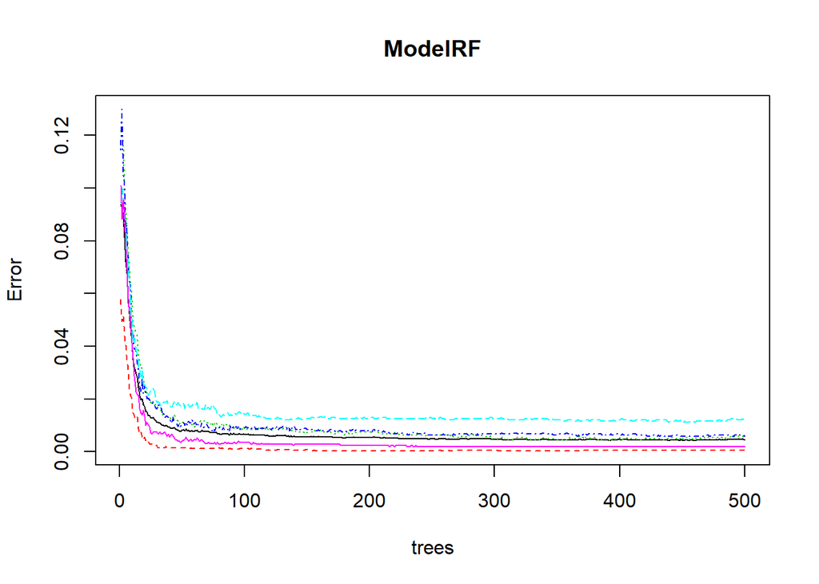

```r
plot(ModelRF)
```

as expected RF lay good result with accurary

## Predicting Results on the Test Data

```r
dim(testingFile)
```

```
## [1]  20 154
```

```r
dim(cleanTestingFile)
```

```
## [1] 20 54
```

```r
ncol(cleanTesting)
```

```
## [1] 54
```

```r
sapply(cleanTesting, class)
```

[output not shown]

```r
ncol(cleanTestingFile)
```

```
## [1] 54
```

```r
sapply(cleanTestingFile, class)
```

[output not shown]

```r
ncol(cleanTestingFile)
```

```
## [1] 54
```

```r
prediction <- predict(ModelRF, newdata=cleanTestingFile)
prediction
```

```
##  1  2  3  4  5  6  7  8  9 10 11 12 13 14 15 16 17 18 19 20
##  B  A  B  A  A  E  D  B  A  A  B  C  B  A  E  E  A  B  B  B
## Levels: A B C D E
```